# Privacy, Proprietary Data and Simulation

6/2/2022

## Privacy, Proprietary Data and Simulation

github: github.com/wdoyle42/qmc22

slidy application: https://wdoyle42.shinyapps.io/aid_simulation/

[figure not shown]

tw: @wdoyle42

em: w.doyle@vanderbilt.edu

## Institutional Aid

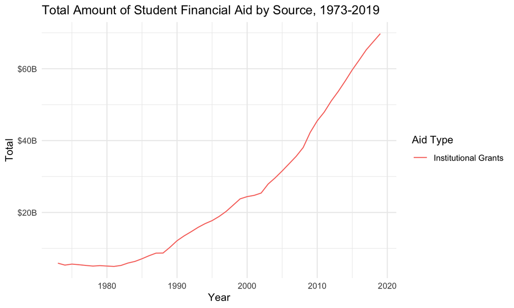

Source: College Board, Trends in Student Aid

## Institutional Aid

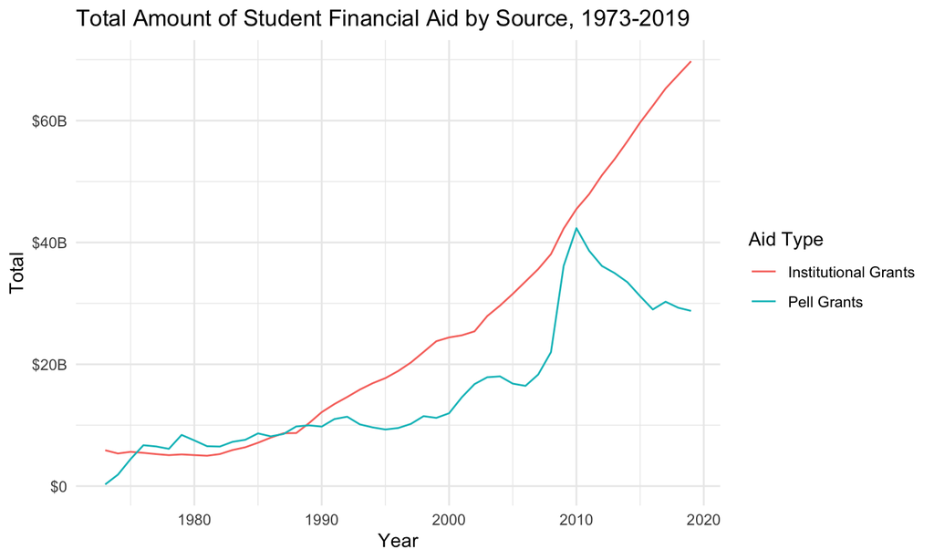

Source: College Board, Trends in Student Aid

## Institutional Aid

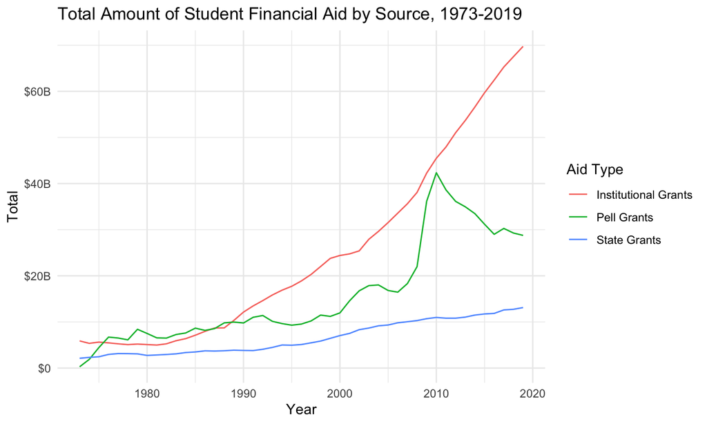

Source: College Board, Trends in Student Aid

## Institutional Aid by Income

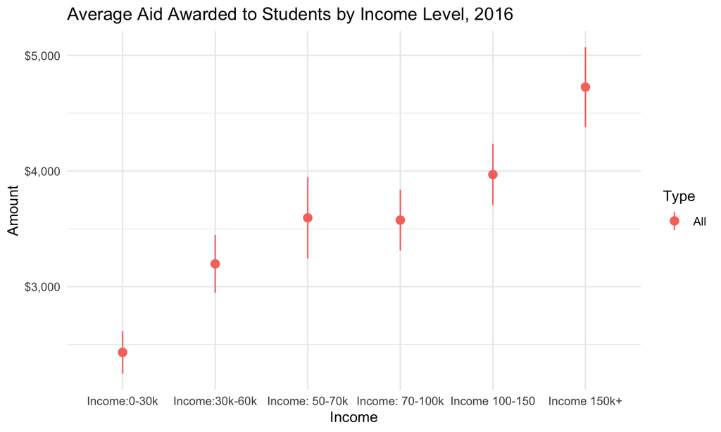

Source: National Postsecondary Student Aid Study

## Institutional Aid by Income

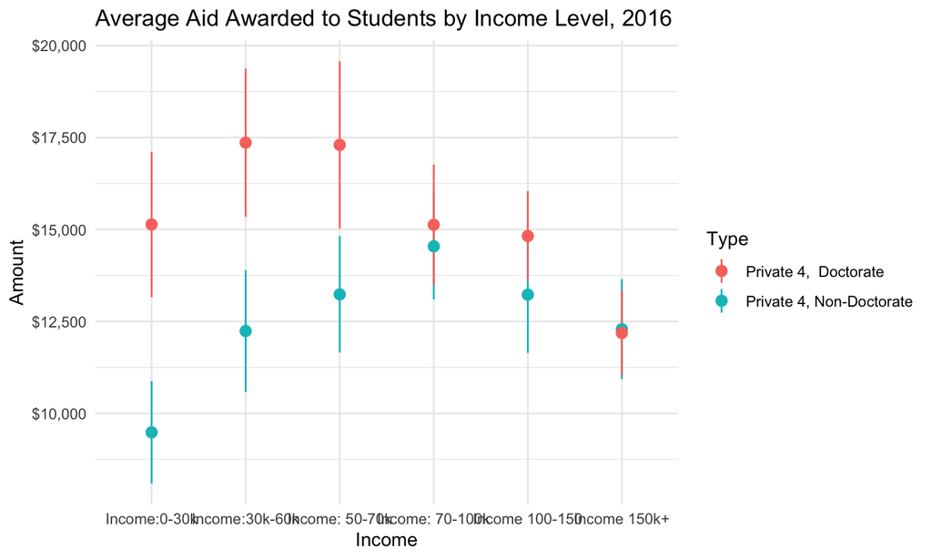

Source: National Postsecondary Student Aid Study

## Institutional Aid by Income

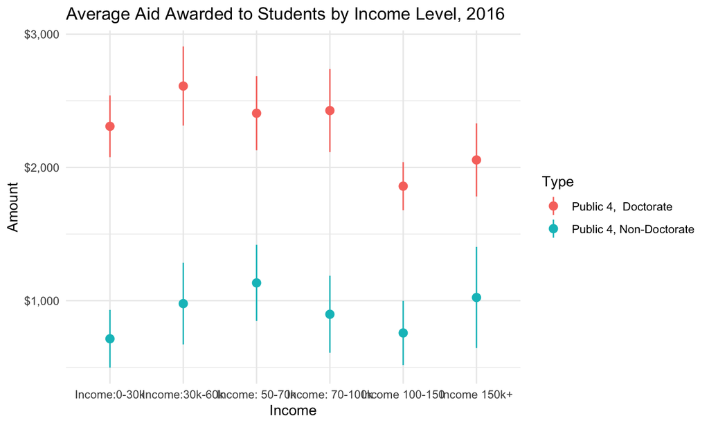

Source: National Postsecondary Student Aid Study

## Predicted Yield by Student Characteristics

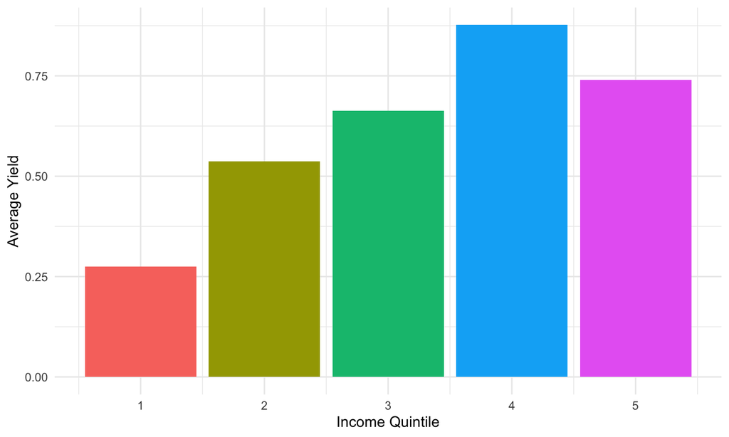

Data simulated from covariances in the High School Longitudinal Study

## Predicted Yield by Student Characteristics

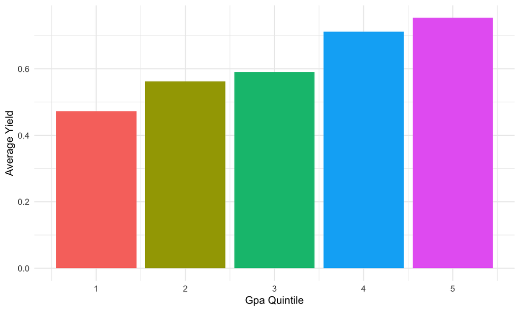

Data simulated from covariances in the High School Longitudinal Study

## Predicted Yield by Student Characteristics

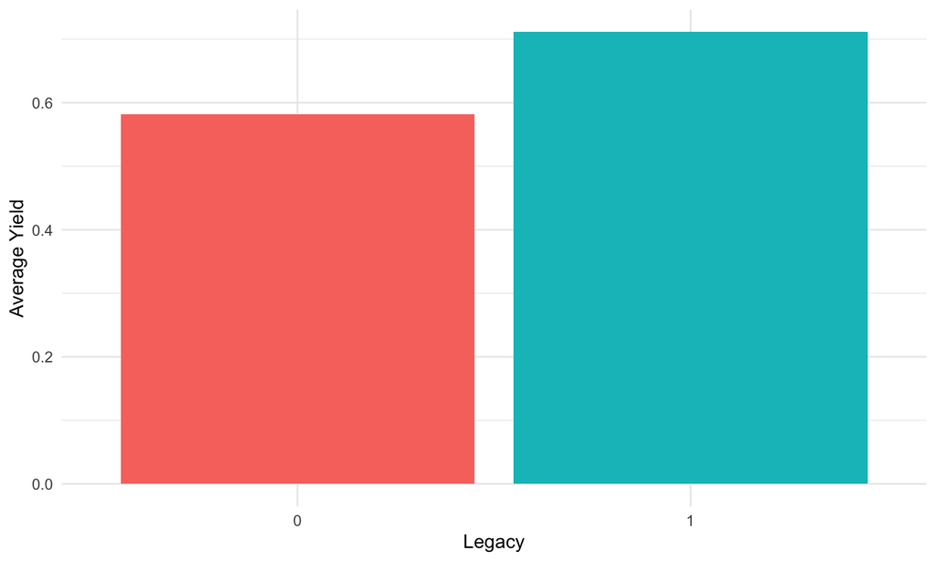

Data simulated from covariances in the High School Longitudinal Study

## Predicted Yield by Student Characteristics

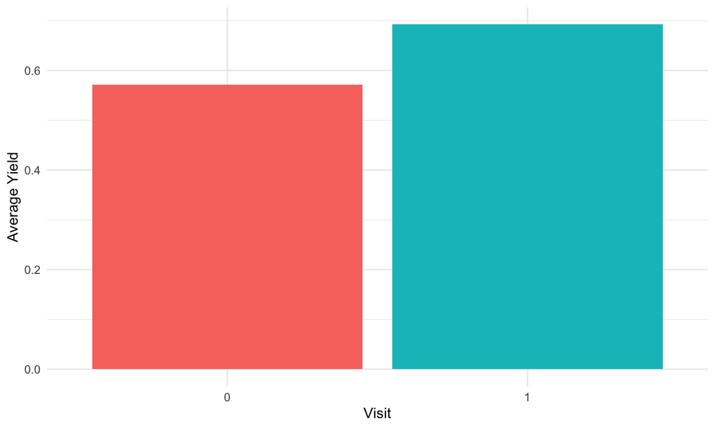

Data simulated from covariances in the High School Longitudinal Study

## Predicted Yield by Student Characteristics

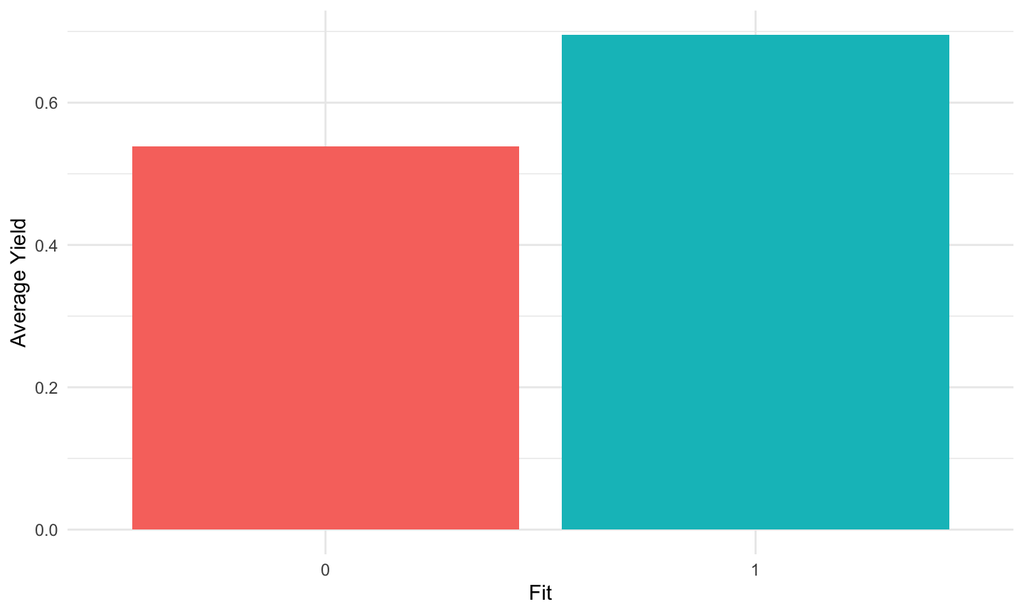

Data simulated from covariances in the High School Longitudinal Study

## Predicted Yield by Student Characteristics

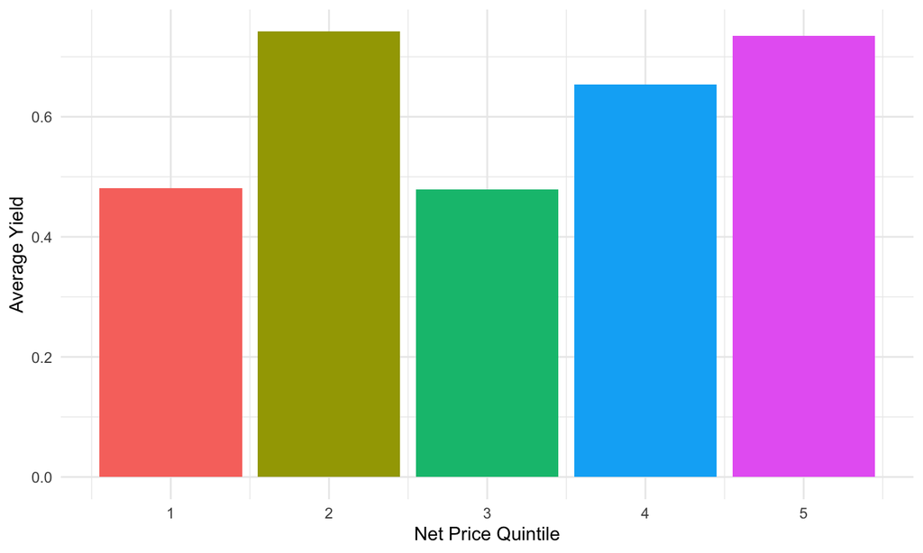

Data simulated from covariances in the High School Longitudinal Study

## Model Fit: Accuracy

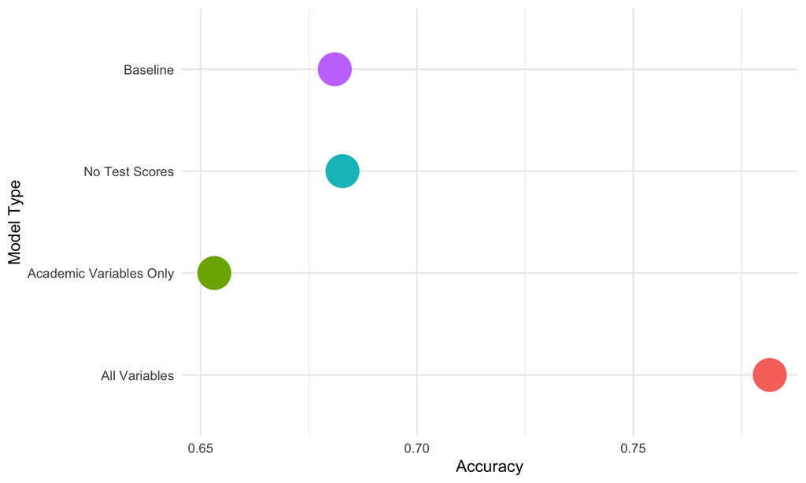

Summary measure of model fit from logistic regression with feature selection via elastic net. Penalty and mixture parameters set from 1000 replicate Monte Carlo cross validation.

## Model Fit: AUC

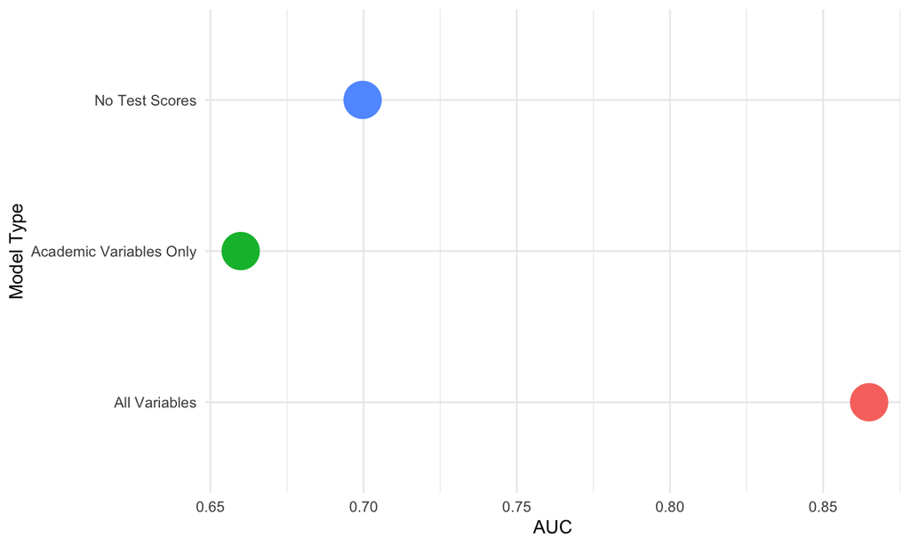

Summary measure of model fit from logistic regression with feature selection via elastic net. Penalty and mixture parameters set from 1000 replicate Monte Carlo cross validation.

## Summarizing Policy Changes: Reducing Net Price for Students With Prob of Enrollment between .45 and .55 by $1,000

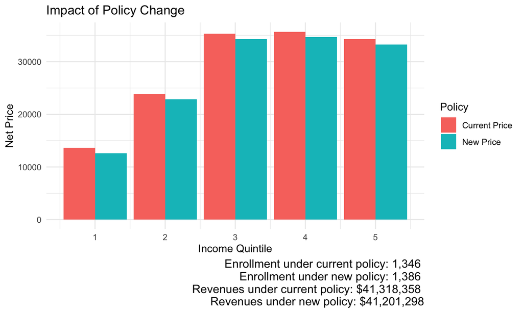

Predictions from best fit model including all variables

## Summarizing Policy Changes: Reducing Net Price for Students With Prob of Enrollment between .45 and .55 by $5,000

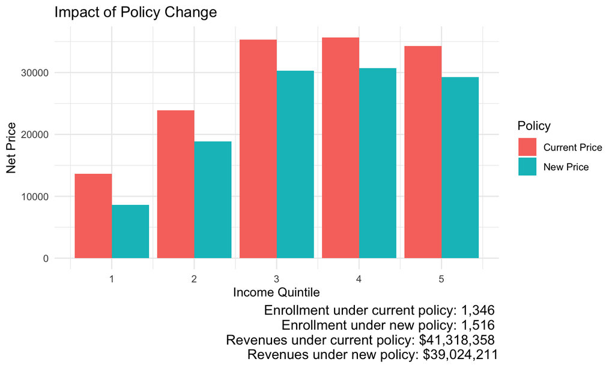

Predictions from best fit model including all variables

## Summarizing Policy Changes: Reducing Net Price for Students With Prob of Enrollment between .45 and .55 by $10,000

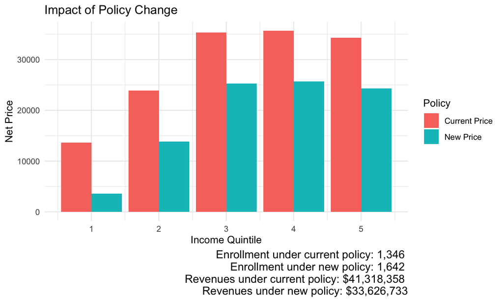

Predictions from best fit model including all variables

## Privacy, Proprietary Data and Simulation

github: github.com/wdoyle42/qmc22

slidy application: https://wdoyle42.shinyapps.io/aid_simulation/

[figure not shown]

tw: @wdoyle42

em: w.doyle@vanderbilt.edu